# A systematic literature review of haptic collaboration

WNJT

2025-08-21

## Keywords search

After our discussion from the meeting on 20.08, I decided to do some keywords search on different databases (e.g., Google scholar, ACM DL, and IEEE Xplore) using the current framing. The goal is to refine our search results and the framing of the introduction. I came across several tutorials about how to identify search terms for running a systematic review. The following document shows what I explored.

The idea is that research team writes a naïve search to capture a set of highly relevant articles (ideally from two databases). The `litsearchr` library imports the naïve search results (`.ris` files), removes duplicates, and extracts keywords to create a document-feature matrix using each possible term. This matrix becomes a keyword co-occurrence network, and `litsearchr` finds a cutoff in keyword importance. Finally, the research team manually considers these keywords and sorts them into concept groups. For detailed information, see [An automated approach to identifying search terms for systematic reviews using keyword co-occurrence networks](https://besjournals.onlinelibrary.wiley.com/doi/10.1111/2041-210X.13268).

## Prepare the demo

```r
packages <- c(#"easyPubMed",
              "litsearchr", "stopwords", "igraph",
              "ggplot2", "ggraph", "ggrepel",
              "rvest", "remotes", "httr"
)
# Install packages not yet installed
installed_packages <- packages %in% rownames(installed.packages())
if (any(installed_packages == FALSE)) {
  install.packages(packages[!installed_packages])
}
# Load packages
lapply(packages, library, character.only = TRUE)
```

[The repository](https://github.com/wenjietseng/slr-haptic-collaboration)

## Naïve search

I prepared two sets of literature for testing `litsearchr`.

1. I collected papers related to haptic collaboration (18 papers) on the Zotero group libray. (let me know if you need access :D)
2. On the ACM DL, I searched with `"shared virtual environment" AND "haptic" AND "virtual reality"`. **Note:** I used shared virtual environment because it seemed to be a subset of remote collaboration. We can further discuss this part.

```r
# setwd if necessary
search_directory <- "./naive_search/"
naive_import <- litsearchr::import_results(search_directory, verbose = TRUE)
```

```
## Reading file ./naive_search//acm.ris ... done
## Reading file ./naive_search//haptic-collaboration-examples.ris ... done
```

```r
table(naive_import$filename)
```

```
##
##                           ./naive_search//acm.ris
##                                                87
## ./naive_search//haptic-collaboration-examples.ris
##                                                18
```

```r
# Removed 11 duplicated papers
naive_results <- litsearchr::remove_duplicates(naive_import, field = "title", method = "string_osa")
table(naive_results$filename)
```

```
##
##                           ./naive_search//acm.ris
##                                                76
## ./naive_search//haptic-collaboration-examples.ris
##                                                18
```

## 1. Identifying keywords

I followed [the tutorial of `litsearchr`](https://rdrr.io/github/elizagrames/litsearchr/f/vignettes/litsearchr_vignette.rmd).

```r
# This part requires more time to figure out the best parameters.
rakedkeywords <-
  litsearchr::extract_terms(
    text = paste(naive_results$title, naive_results$abstract),
    method = "fakerake",
    min_freq = 2,
    ngrams = TRUE,
    min_n = 2,
    language = "English"
  )

taggedkeywords <-
  litsearchr::extract_terms(
    keywords = naive_results$keywords,
    method = "tagged",
    min_freq = 2,
    ngrams = TRUE,
    min_n = 2,
    language = "English"
  )
```

## 2. Build the keyword co-occurrence network

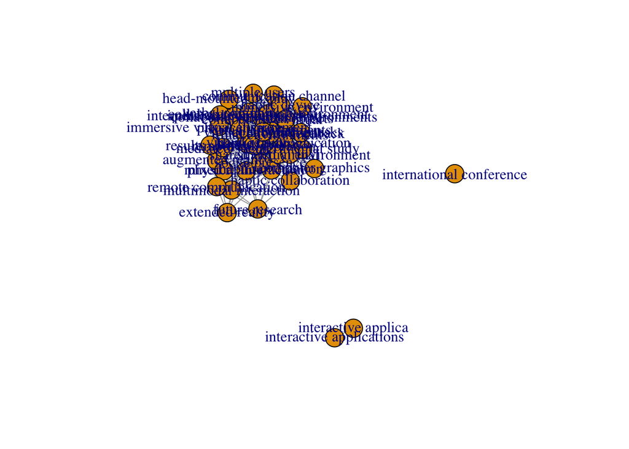

```r
all_keywords <- unique(append(taggedkeywords, rakedkeywords))

naivedfm <-
  litsearchr::create_dfm(
    elements = paste(naive_results$title, naive_results$abstract),
    features = all_keywords
  )

# This part requires more time to figure out the best parameters.
naivegraph <-
  litsearchr::create_network(
    search_dfm = naivedfm,
    min_studies = 3,
    min_occ = 3
  )

# This plot is hard to read because we haven't decided the cutoff
# improve the plot
plot(naivegraph)
```

## 3. Identify change points in keyword importance

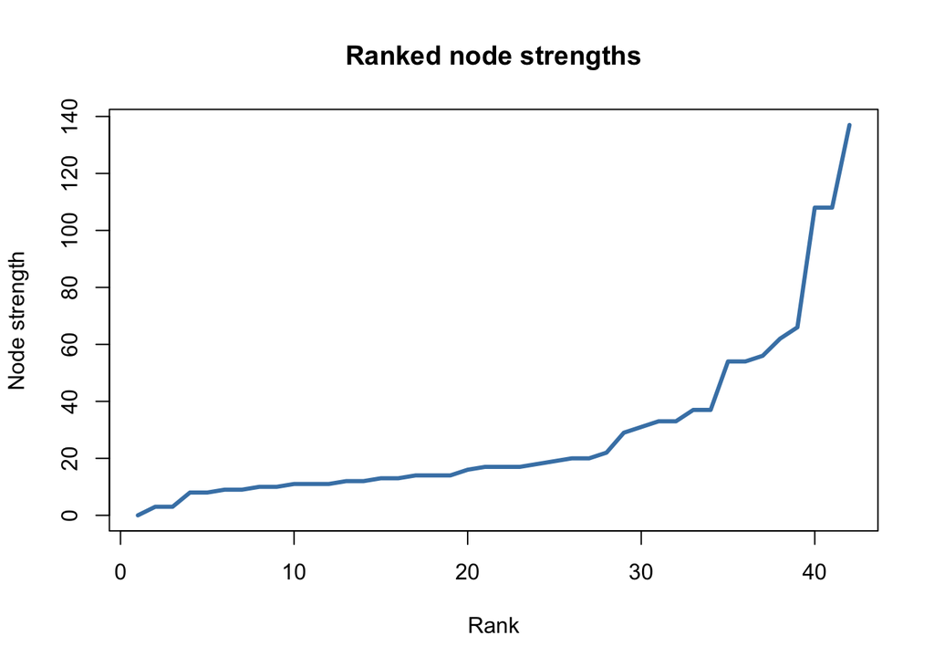

```r
plot(sort(igraph::strength(naivegraph)),
     ylab = "Node strength",
     xlab = "Rank",
     main = "Ranked node strengths",
     type = "l",
     lwd = "3",
     col = "steelblue"
     )
```

```r
# This part requires more time to figure out the best parameters.
cutoff <-
  find_cutoff(graph=naivegraph, method = "cumulative",
              percent = 0.8,
              imp_method = "strength"
  )
cutoff
```

```
## [1] 17
```

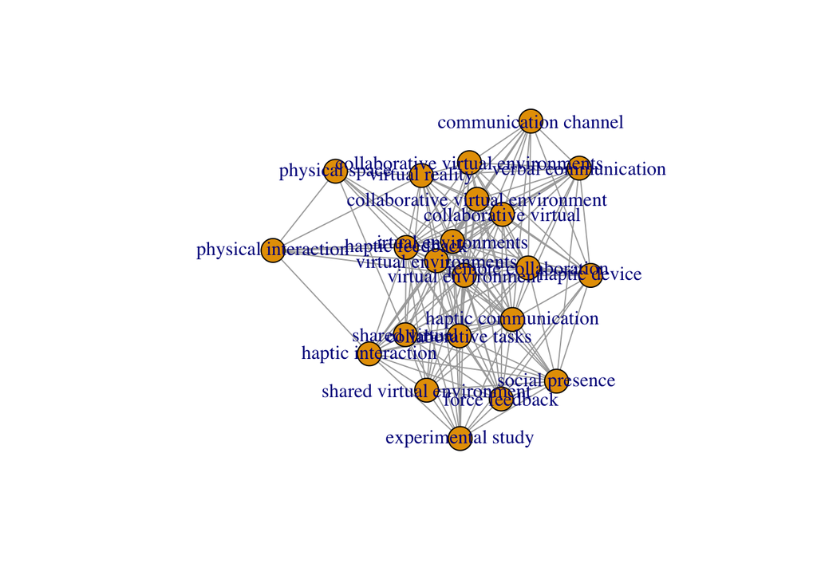

```r
reduced_graph <- reduce_graph(naivegraph, cutoff_strength = cutoff)

#improve the plot
plot(reduced_graph)
```

Now the network looks better.

## 4. Group terms into concepts

| x |
| --- |
| collaborative virtual environments |
| haptic interaction |
| virtual environments |
| virtual reality |
| collaborative tasks |
| collaborative virtual |
| collaborative virtual environment |
| communication channel |
| experimental study |
| force feedback |
| haptic communication |
| haptic device |
| haptic feedback |
| irtual environments |
| physical interaction |
| physical space |
| remote collaboration |
| shared virtual |
| shared virtual environment |
| social presence |
| verbal communication |
| virtual environment |

This is a list of keywords we extracted using `litsearchr`. I put them in a [speadsheet](https://docs.google.com/spreadsheets/d/1HbytdU0FtkgHbPHDnlrCuFwx5BAzkleRjizcoVzX_eQ/edit?usp=sharing) so we can group them and finalize our search terms. If you see the spreadsheet, two larger groups are haptic and scenarios (shared/collaborative virtual environments).

## 5. Write Boolean searches

**TO DO:** See how they decide the final search terms.

This part creates an output for the formal search. We don’t need it at this moment.

## 6. Check search strategy precision and recall

This part is to double check if our targeted papers exist in the search results from the refined search terms. I have a set of haptic collaboration papers, we can also discuss what we want to include in this list for the final check.

## Next steps

decide on the goldend standard list of papers 25

A. Gilles shared with me the approach of identifying search terms:

1. find a set of about 25 relevant papers you want include in your survey
2. identify the key terms that appear relevant in title, abstract, keywords (and potientially the full article if necessary)
3. use the key terms to elaborate you final query
4. iterate on the query to find a good compromise between
   - total number of article (we want to review not more than ~200 papers)
   - you initial set of papers should be covered at least at 75% by your query.
   - iteration is also interesting to justify your exclusion criteria and potential problem / limitations.

B. [Google spread sheet and search outputs](https://docs.google.com/spreadsheets/d/1HbytdU0FtkgHbPHDnlrCuFwx5BAzkleRjizcoVzX_eQ/edit?usp=sharing)

C. [Automated systematic literature search using R, litsearchr, and Google Scholar web scraping](https://www.r-bloggers.com/2023/03/automated-systematic-literature-search-using-r-litsearchr-and-google-scholar-web-scraping/)